# Cyclistic Case Study: How Does a Bike-Share Navigate Speedy Success?

## 4. Analyze

### Basic Statistics

```r
summary_stats <- Divvy_tripdata %>%
  summarise(
    mean_ride_length = mean(ride_length),
    median_ride_length = median(ride_length),
    max_ride_length = max(ride_length),
    min_ride_length = min(ride_length))
kable(summary_stats)
```

| mean_ride_length | median_ride_length | max_ride_length | min_ride_length |
| --- | --- | --- | --- |
| 16.482 | 10.17325 | 1439.385 | 1.000017 |

### By User Type

```r
summary_stats_2 <- Divvy_tripdata %>%
  group_by(member_casual) %>%
  summarise(
    total_rides = n(),
    avg_duration = mean(ride_length),
    median_duration = median(ride_length),
    rides_weekend_perc = sum(day_type == "Weekend") / n() * 100)
kable(summary_stats_2)
```

| member_casual | total_rides | avg_duration | median_duration | rides_weekend_perc |
| --- | --- | --- | --- | --- |
| casual | 1622232 | 23.55465 | 13.362983 | 38.09659 |
| member | 2755085 | 12.31753 | 8.816917 | 23.51125 |

### Most Popular Day

```r
mode_day <- Divvy_tripdata %>%
  count(day_of_week) %>%
  arrange(desc(n)) %>%
  slice(1)
```

[output not shown]

### Average ride length by user type and day

```r
avg_ride_by_type_day <- Divvy_tripdata %>%
  group_by(member_casual, day_of_week) %>%
  summarise(avg_ride_length = mean(ride_length))
```

| User Type | Day of the Week | Average Ride Length |
| --- | --- | --- |
| casual | Monday | 22.59759 |
| casual | Tuesday | 20.54972 |
| casual | Wednesday | 20.51346 |
| casual | Thursday | 20.93306 |
| casual | Friday | 22.97448 |
| casual | Saturday | 26.56174 |
| casual | Sunday | 26.88533 |
| member | Monday | 11.73705 |
| member | Tuesday | 11.77046 |
| member | Wednesday | 11.89111 |
| member | Thursday | 11.85737 |
| member | Friday | 12.14726 |
| member | Saturday | 13.72069 |
| member | Sunday | 13.78258 |

### Top Stations

```r
top_stations <- Divvy_tripdata %>%
  group_by(member_casual, start_station_name) %>%
  summarise(rides = n()) %>%
  arrange(member_casual, desc(rides)) %>%
  group_by(member_casual) %>%
  slice(1:10)
```

| member_casual | start_station_name | rides |
| --- | --- | --- |
| casual | Streeter Dr & Grand Ave | 51604 |
| casual | DuSable Lake Shore Dr & Monroe St | 34364 |
| casual | Michigan Ave & Oak St | 25189 |
| casual | DuSable Lake Shore Dr & North Blvd | 22893 |
| casual | Millennium Park | 22289 |
| casual | Shedd Aquarium | 20895 |
| casual | Dusable Harbor | 18842 |
| casual | Theater on the Lake | 16664 |
| casual | Michigan Ave & 8th St | 13226 |
| casual | Adler Planetarium | 12253 |
| member | Kingsbury St & Kinzie St | 30459 |
| member | Clinton St & Washington Blvd | 25368 |
| member | Clinton St & Madison St | 23353 |
| member | Clark St & Elm St | 23166 |
| member | Canal St & Madison St | 20158 |
| member | Clinton St & Jackson Blvd | 19533 |
| member | State St & Chicago Ave | 18619 |
| member | Wells St & Elm St | 18541 |
| member | Wells St & Concord Ln | 18392 |
| member | Dearborn St & Erie St | 17287 |

### Seasonal Usage

```r
seasonal_usage <- Divvy_tripdata %>%
  group_by(season, member_casual) %>%
  summarise(
    avg_ride_length = mean(ride_length),
    total_rides = n())
```

| season | member_casual | avg_ride_length | total_rides |
| --- | --- | --- | --- |
| Autumn | casual | 21.64478 | 441108 |
| Autumn | member | 11.88422 | 783969 |
| Spring | casual | 21.98043 | 261922 |
| Spring | member | 11.68382 | 541390 |
| Summer | casual | 25.73935 | 854737 |
| Summer | member | 13.42133 | 1154585 |
| Winter | casual | 14.05237 | 64465 |
| Winter | member | 10.16720 | 275141 |

### Bike Share

```r
bike_share <- Divvy_tripdata %>%
  group_by(member_casual, rideable_type) %>%
  summarise(rides = n(), .groups = "drop") %>%
  group_by(member_casual) %>%
  mutate(percent = round(100 * rides / sum(rides), 1))
```

| member_casual | rideable_type | rides | percent |
| --- | --- | --- | --- |
| casual | classic_bike | 978976 | 60.3 |
| casual | electric_bike | 617983 | 38.1 |
| casual | electric_scooter | 25273 | 1.6 |
| member | classic_bike | 1680799 | 61.0 |
| member | electric_bike | 1052613 | 38.2 |
| member | electric_scooter | 21673 | 0.8 |

## Summary of Findings

### Key Metrics Comparison

[output not shown]

### Bike Type Preferences

Both Members and Casual show close bike preferences:

- Classic Bikes: ~60%
- Electric Bikes: ~38%
- Electric Scooters: ~1%

## 5. Share

### Key Question Answered

*How do annual members and casual riders use Cyclystic bikes differently?*

### Summary:

- **Casual Riders**: Leisure-oriented, prefer weekends, long rides, tourist locations
- **Members**: Commute-focused, ride more during weekdays and rush hours, prefer business district stations

### Vizualizations

#### Ride Frequency and Duration

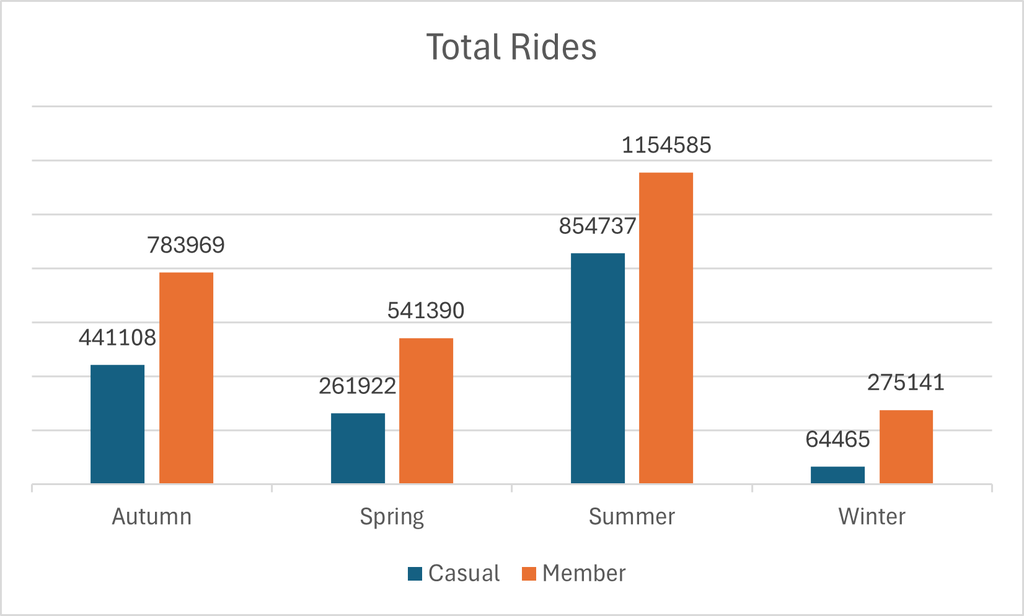

**Insight**: Members significantly outnumber casual riders in total trips, highlighting their consistent usage.

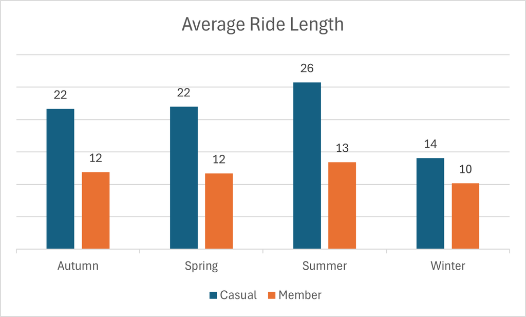

**Surprise**: Casual riders’ average ride length is nearly double that of members, reinforcing the idea for leisurely use.

#### Time-Based Usage Patterns

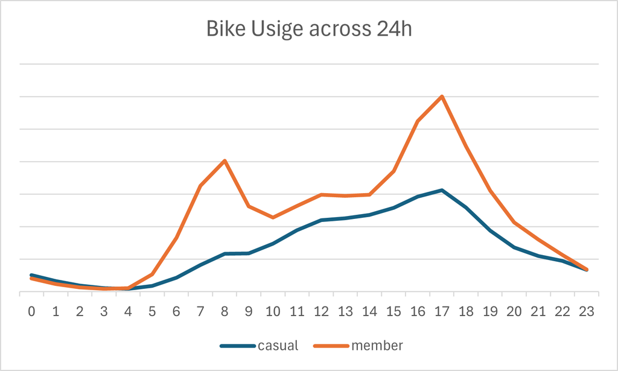

**Insight**: Members show clear peaks during rush hours (7–9 and 16–18), aligning with work commutes. Casual rides are more evenly distributed, with slight peaks on the afternoon.

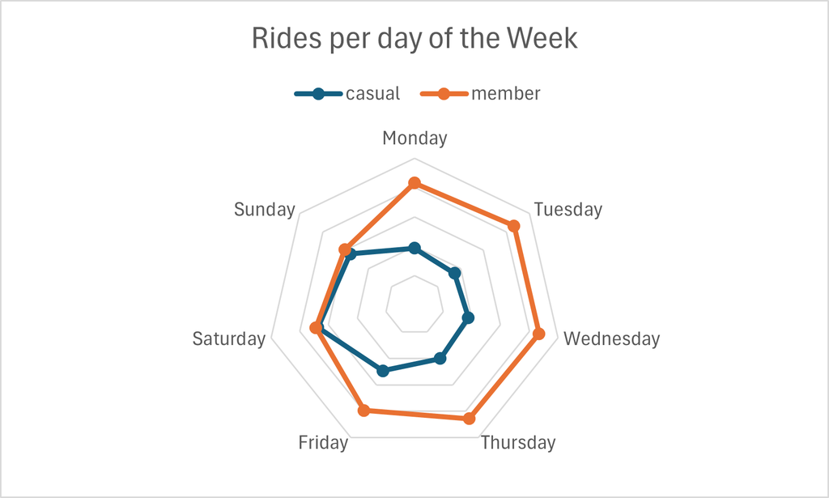

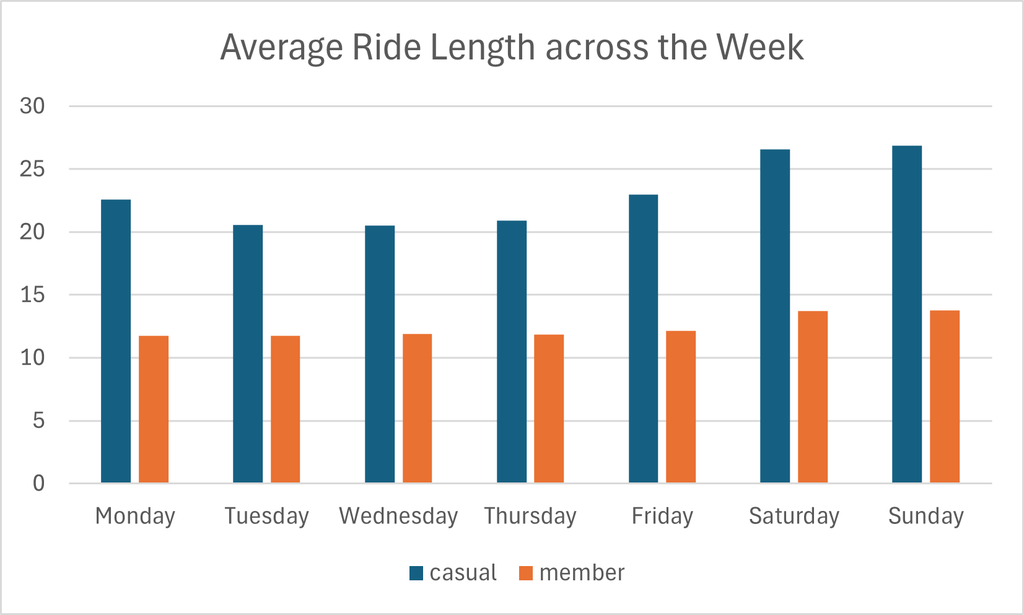

**Insight**: Again it shouwcases Casual riders’ trips being consistently longer than members’, with both groups riding slightly longer on weekends.

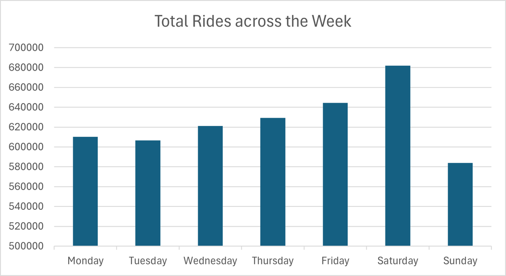

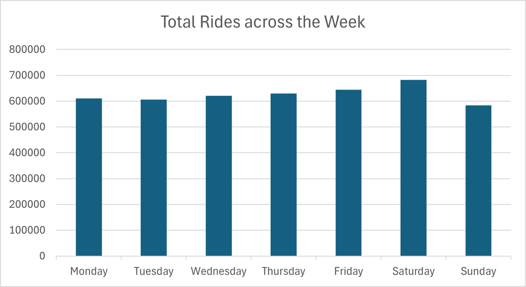

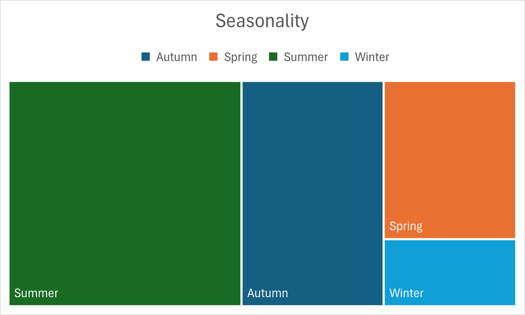

*Insight*: Seasonal patterns align with expectations—higher ridership in warmer months and lower in the colder ones.

#### Bike Type Preferences

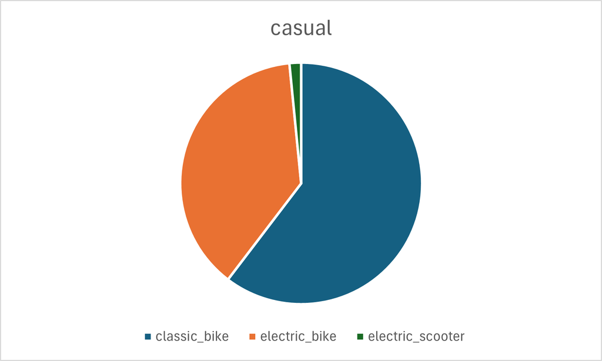

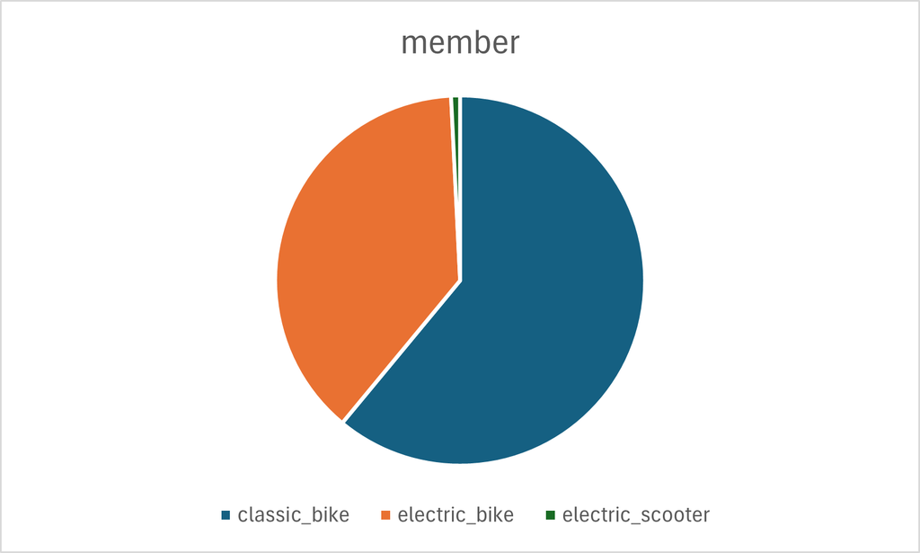

#### Most Popular Start Stations

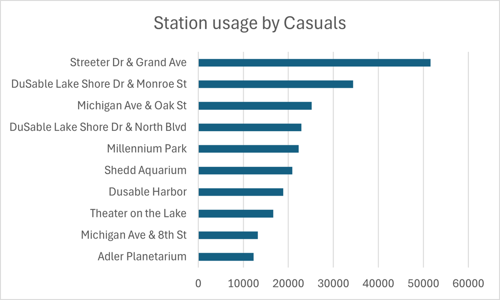

**Insight**: Casual riders frequent tourist-heavy areas (e.g., Streeter Dr & Grand Ave near Navy Pier).

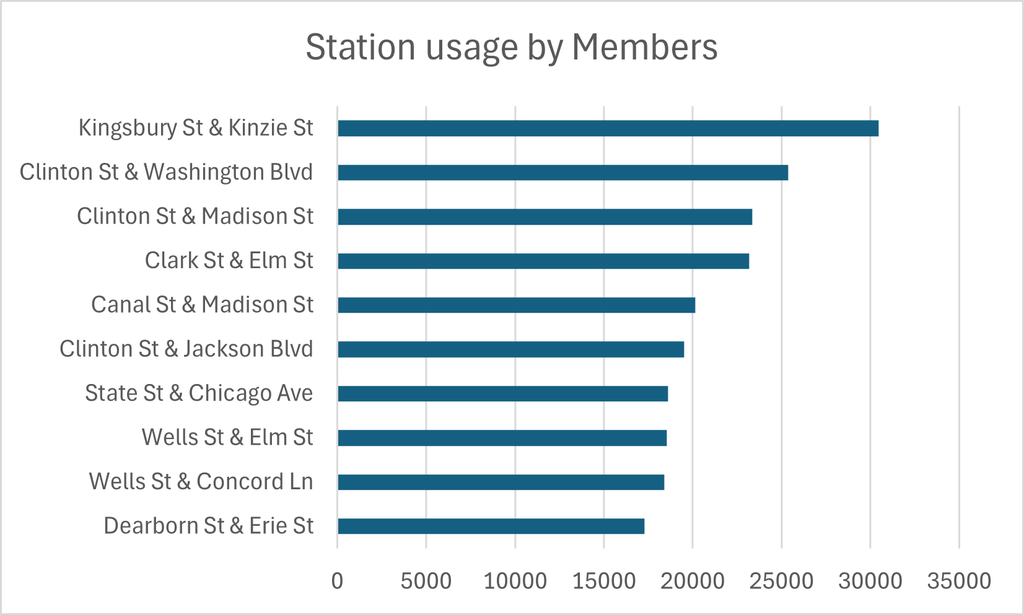

**Insight**: Members prioritize stations near business districts (e.g., Kingsbury St & Kinzie St in the West Loop).

## 6. Act

### Strategic Recommendations

- **Weekend Memberships**: Introduce an “Unlimited Weekends” pass
- **Seasonal Campaigns**: Offer summer deals and winter loyalty perks
- **Commuter Conversion**: Target casuals with frequent weekday use

# Final Reflections

This Cyclistic case study was my first hands-on project after completing the Google Data Analytics Certificate. It helped me apply what I learned — especially data cleaning, transformation, and visualization — to a real-world business problem.

Working with real data had its challenges, like missing values and inconsistent formats, but it also showed the importance of staying organized and following a clear process. I analyzed patterns in user behavior, such as seasonal trends, and turned those insights into simple, practical recommendations.

This project is my starting point in building a strong data portfolio. The steps I followed — asking the right questions, preparing and analyzing the data, and sharing insights — will guide my future work in analytics.

Anatoli Ignatov